# Spotted Lanternfly (*Lycorma delicatula*)

Pest species atlas

2024-11-23

[figure not shown]

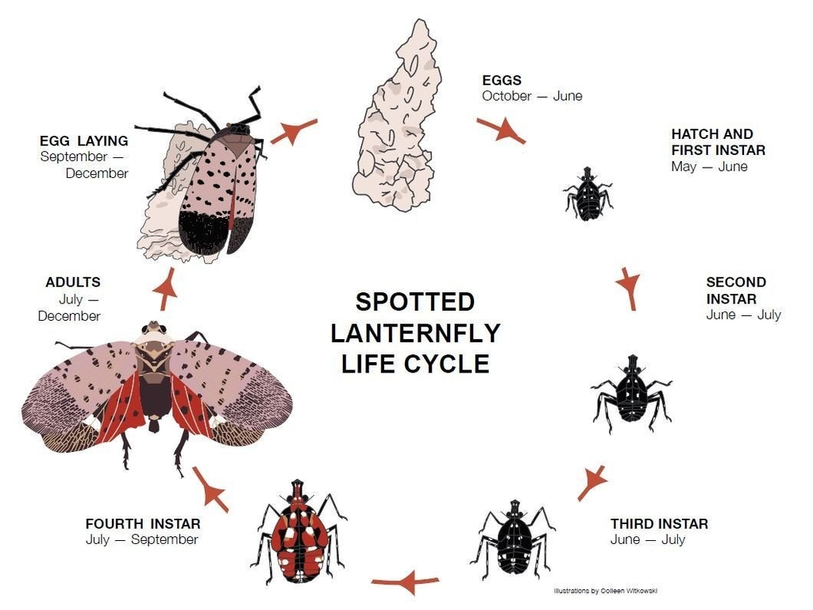

Pictures from [Bartlett Tree Experts](https://www.bartlett.com/blog/spotted-lanternfly-control-treatment/) and [University of Rhode Island](https://web.uri.edu/biocontrol/spotted-lanternfly/slf-distribution-identification-life-cycle/)

### Background

The Spotted Lanternfly (*Lycorma delicatula*), an invasive pest native to China, was first identified in Pennsylvania in September 2014. This pest has a broad dietary range, feeding on numerous fruit, ornamental, and woody trees, particularly favoring the invasive tree-of-heaven (*Ailanthus altissima*). It can spread over long distances when people move materials or items infested with egg masses.

Juvenile Spotted Lanternflies, known as nymphs, and adults feed on an array of crops and plants, including, but not limited to, almonds, apples, apricots, cherries, grapes, hops, maple trees, nectarines, oak trees, peaches, pine trees, plums, poplar trees, sycamore trees, walnut trees, and willow trees. The feeding habits of both nymphs and adults inflict significant damage to these plants.

When feeding, Spotted Lanternflies suck sap from stems and branches, reducing photosynthesis and weakening the plant, which can eventually lead to the plant’s death. Furthermore, their feeding often results in the plant oozing or weeping, giving off a fermented odor. These insects also excrete substantial amounts of fluid known as honeydew, which can promote mold growth and attract other insects, exacerbating the issue. Potential climate change effects, including shifts in temperature and precipitation patterns, may alter the geographic distribution of the Spotted Lanternfly. Such changes could enable the pest to establish in new regions, amplifying concerns in agriculture and forestry sectors.

For more information, visit the [USDA](https://www.aphis.usda.gov/aphis/resources/pests-diseases/hungry-pests/the-threat/spotted-lanternfly/spotted-lanternfly) website or view their [Pest Alert](https://www.aphis.usda.gov/publications/plant_health/alert-spotted-lanternfly.pdf)

## Data collected from Global Biodiversity Information Facility (GBIF)

Records were downloaded from [GBIF](https://www.gbif.org/species/5157899) and filtered to include only iNaturalist research-grade observations.  
GBIF.org (25 May 2023) GBIF Occurrence Download https://doi.org/10.15468/dl.hxkqzb

## Predicted Current and Future Habitat Suitability (0-1) of Spotted Lanternfly using research-grade iNaturalist observations

The raster layers of this map are the predicted current and future habitat suitability of Spotted Lanternflys, with low predicted suitability in blue, increasing suitability in green and then yellow, and highest suitability in orange and red.

[output not shown]

[interactive chart not shown]

**You can toggle the visible layers by checking and un-checking the “Current Projected Distribution” and “Future Projected Distribution” in the top right box.** In the coming years, it is likely the distribution may shift northwards and away from the coast. Additionally, the habitat suitability will increase in inland areas it is already found.

### Top Predictors

The top predictors of current habitat suitability of the Spotted Lanternfly included:

1. bio15: Precipitation Seasonality
2. bio 9: Mean Temperature of Driest Quarter
3. bio 3: Isothermality
4. kg5: Köppen-Geiger climate classification

### Model information

The ‘current’ model was created using the GBIF iNaturalist data points and a cross-validated random forest algorithm. Variables included in the model were [CHELSA + variables](https://chelsa-climate.org/exchelsa-extended-bioclim/) from 1981–2010 using the NOAA Earth system model (more information [here](https://www.envidat.ch/dataset/21d662b7-9c59-41da-aa82-7d8a879b8db7/resource/aa676d1f-5f7f-479b-af20-26066b0537d1/download/chelsa_file_specification_bioclim_plus.pdf)).

The future (2041-2070) distribution layer was created using the top model of its current distribution on projected future [CHELSA + variables](https://chelsa-climate.org/exchelsa-extended-bioclim/) in 2041-2070 assuming the ‘worst-case scenario’ shared socioeconomic pathway SSP585 and using the NOAA Earth system model (more information [here](https://www.envidat.ch/dataset/21d662b7-9c59-41da-aa82-7d8a879b8db7/resource/aa676d1f-5f7f-479b-af20-26066b0537d1/download/chelsa_file_specification_bioclim_plus.pdf)).